# final-assignment

Eray Ferah

28 05 2022

```
##  Hlavac, Marek (2022). stargazer: Well-Formatted Regression and Summary Statistics Tables.
```

```
##  R package version 5.2.3. https://CRAN.R-project.org/package=stargazer
```

```
##
## t test of coefficients:
##
##             Estimate Std. Error t value Pr(>|t|)
## (Intercept) 0.323897   0.279328  1.1596   0.2469
## mktrf       1.134783   0.061361 18.4934   <2e-16 ***
## ---
## Signif. codes:  0 '***' 0.001 '**' 0.01 '*' 0.05 '.' 0.1 ' ' 1
```

```
##
## ===============================================
##                         Dependent variable:
##                     ---------------------------
##                           Excess_Returns
## -----------------------------------------------
## mktrf                        1.135***
##                               (0.061)
##
## Constant                       0.324
##                               (0.279)
##
## -----------------------------------------------
## Observations                    431
## R2                             0.444
## Adjusted R2                    0.442
## Residual Std. Error      5.720 (df = 429)
## F Statistic          342.007*** (df = 1; 429)
## ===============================================
## Note:               *p<0.1; **p<0.05; ***p<0.01
```

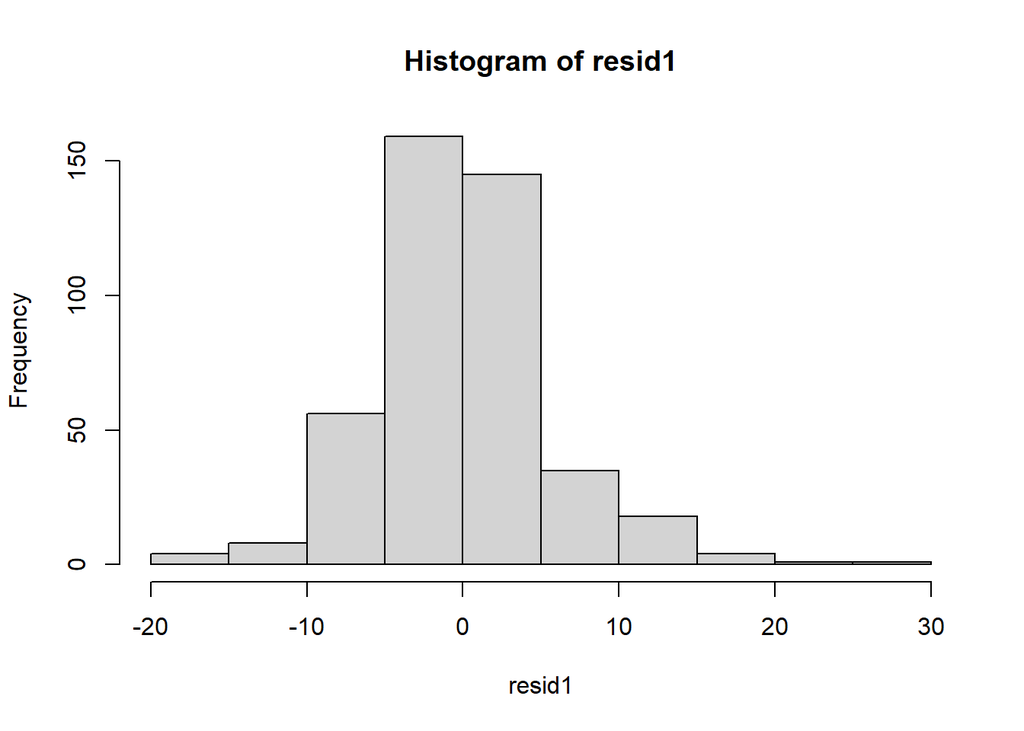

[output not shown]

I have built CAPM Model with Disney stock excess return and mktrf.

Below I will be doing hypothesis testing for intercept and independent variable (t-tests)

## (1) intercept coefficient = 0.

## (2) mktrf coefficient = 1.

```r
library(car)
library(lmtest)
library(dplyr)
library(strucchange)
##### Project 1: Hypothesis testing #####
# show t test for a=0 b=0 c=0
summary(Model_1_dis)$coefficients
```

```
##              Estimate Std. Error   t value     Pr(>|t|)
## (Intercept) 0.3238965 0.27932821  1.159555 2.468749e-01
## mktrf       1.1347825 0.06136134 18.493444 1.408434e-56
```

```r
# Test a=0 with t test
Model_1_dis$coefficients[1]/sqrt(diag(vcov(Model_1_dis)))[1]
```

```
## (Intercept)
##    1.159555
```

```r
linearHypothesis(Model_1_dis, c("(Intercept)=0"))
```

```
## Linear hypothesis test
##
## Hypothesis:
## (Intercept) = 0
##
## Model 1: restricted model
## Model 2: Excess_Returns ~ mktrf
##
##   Res.Df   RSS Df Sum of Sq      F Pr(>F)
## 1    430 14078
## 2    429 14034  1    43.986 1.3446 0.2469
```

```r
# Test b=1 with t test
linearHypothesis(Model_1_dis, c("mktrf=1"))
```

```
## Linear hypothesis test
##
## Hypothesis:
## mktrf = 1
##
## Model 1: restricted model
## Model 2: Excess_Returns ~ mktrf
##
##   Res.Df   RSS Df Sum of Sq      F  Pr(>F)
## 1    430 14192
## 2    429 14034  1    157.84 4.8248 0.02859 *
## ---
## Signif. codes:  0 '***' 0.001 '**' 0.01 '*' 0.05 '.' 0.1 ' ' 1
```

Null hypothesis, that intercept coefficient is 0, is failed to be rejected (p-value 0.2469).

Null hypothesis, that mktrf coefficient is 1, is rejected at 5 % significance level (p-value 0.02859)

## F Test that intercept coefficient is 0 and indep variable coefficient is 1.

```r
# Test a=0 and b=1 with f test
linearHypothesis(Model_1_dis, c("(Intercept)=0", "mktrf=1"))
```

```
## Linear hypothesis test
##
## Hypothesis:
## (Intercept) = 0
## mktrf = 1
##
## Model 1: restricted model
## Model 2: Excess_Returns ~ mktrf
##
##   Res.Df   RSS Df Sum of Sq      F  Pr(>F)
## 1    431 14270
## 2    429 14034  2    235.72 3.6028 0.02808 *
## ---
## Signif. codes:  0 '***' 0.001 '**' 0.01 '*' 0.05 '.' 0.1 ' ' 1
```

We reject the null hypothesis that intercept coefficient is 0 and mktrf’s coefficient is 1 at 5 % significance level. (p-value 0.02808).

# Diagnostic Tests

## Linearity test

```r
# Test for linearity of the Model using the RAMSEY reset test
resettest(Model_1_dis, power=2:4, type="fitted")
```

```
##
##  RESET test
##
## data:  Model_1_dis
## RESET = 0.82902, df1 = 3, df2 = 426, p-value = 0.4784
```

According to the RESET test (null hypothesis is that model is not suffering omitted variable problem), model is linear (p-value 0.4784).

## Autocorrelation test

```r
dwtest(Model_1_dis)
```

```
##
##  Durbin-Watson test
##
## data:  Model_1_dis
## DW = 2.1436, p-value = 0.932
## alternative hypothesis: true autocorrelation is greater than 0
```

According to Durbin-Watson test, the null hypothesis that autocorrelation of residuals is 0 and p-value is 0.932. So we fail to reject null hypothesis and say that there is no auto correlation among residuals.

## Heteroscedasticity test

```r
bptest(Model_1_dis, ~ I(mktrf^2), data = df_dis)
```

```
##
##  studentized Breusch-Pagan test
##
## data:  Model_1_dis
## BP = 1.5345, df = 1, p-value = 0.2154
```

According to white-test, which null hypothesis homoscedasticity is present, our model is homoscedastic. p-value 0.2154

## Normality test

```r
library(tseries)
jarque.bera.test(resid1)
```

```
##
##  Jarque Bera Test
##
## data:  resid1
## X-squared = 114.24, df = 2, p-value < 2.2e-16
```

## Multicollinearity test

Since CAPM model is simple linear regression (1 independent variable), there is no need for multicollinearity test. However, if there has been more than 1 independent variable we should check a correlation matrix amon independent variables.

```r
library(plm)
model_dis <- Excess_Returns ~ mktrf

#phtest(plm(model_dis, data = df_dis, model = "within"), data = df_dis)
```